# Upgrade SQL

Enrique ESCOBAR

28-07-2016

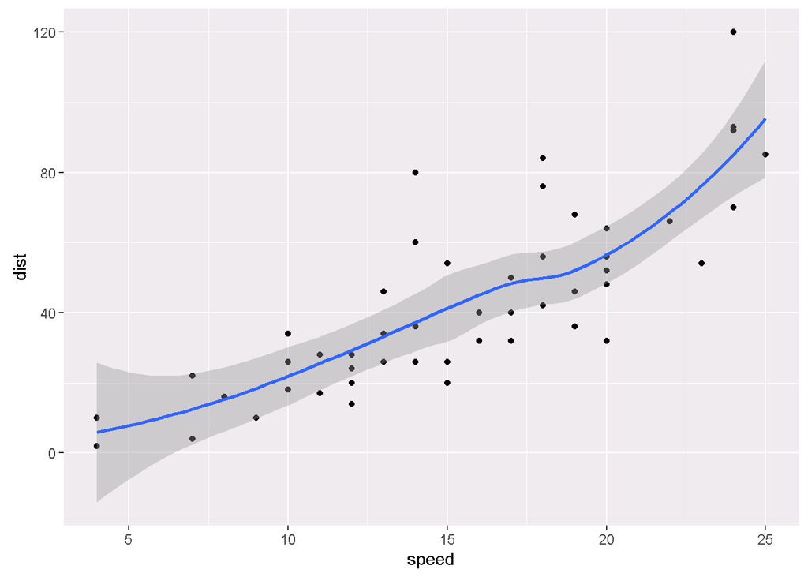

```r
library(ggplot2)
qplot(speed, dist, data = cars) + geom_smooth()
```

# Analysis

```
## [1] "D:/Axon-ID/R/SqlODBC"
```

```
## Load Util........    Lib/base.Util.R
```

```
## Load Util........    Lib/RODBC.Util.R
```

```
## Load Util........    Lib/ggplot2.Util.R
```

```
## Load Util........    Lib/plotrix.Util.R
```

## Setup R

The best tool to do statistical analysis and graph is R (integrated in SQL Server 2016).

## Screening Server

### Server Info

```r
# Server info
serverInstance <- SqlCountResultToString(simmqODBC, "Select @@SERVERNAME     AS SQLServerInstance;");
```

```
## W2K8MMQSQL02
```

```r
serverVersion <- SqlCountResultToString(simmqODBC, "Select @@VERSION        AS SQLServerVersion;");
```

```
## Microsoft SQL Server 2008 R2 (SP1) - 10.50.2550.0 (X64)
##  Jun 11 2012 16:41:53
##  Copyright (c) Microsoft Corporation
##  Developer Edition (64-bit) on Windows NT 6.1 <X64> (Build 7601: Service Pack 1) (Hypervisor)
```

```r
serverService <- SqlCountResultToString(simmqODBC, "Select @@ServiceName    AS ServiceInstance;");
```

```
## MSSQLSERVER
```

### Server Running

```r
# Server Running
sqlFile <- "SQL/DB-ServerRunning_list.sql";
sqlDataFrame <- SqlResultToDataFrame(simmqODBC, GetSqlFromFile(sqlFile));
```

```
## SELECT  @@SERVERNAME                                    AS ServerName         , @@SERVICENAME                                 AS ServiceName         , create_date                                   AS ServerStarted         , DATEDIFF(s, create_date, GETDATE()) / 86400.0 AS DaysRunning FROM    sys.…
## 9
```

```r
sqlDataFrame;
```

```
##     ServerName ServiceName       ServerStarted DaysRunning
## 1 W2K8MMQSQL02 MSSQLSERVER 2003-04-08 09:13:36 4861.269294
## 2 W2K8MMQSQL02 MSSQLSERVER 2016-07-28 10:14:35    1.226944
## 3 W2K8MMQSQL02 MSSQLSERVER 2003-04-08 09:13:36 4861.269294
## 4 W2K8MMQSQL02 MSSQLSERVER 2010-04-02 17:35:08 2309.921007
## 5 W2K8MMQSQL02 MSSQLSERVER 2015-12-17 15:33:04  225.005775
## 6 W2K8MMQSQL02 MSSQLSERVER 2015-12-17 15:33:04  225.005775
## 7 W2K8MMQSQL02 MSSQLSERVER 2015-12-17 15:53:02  224.991910
## 8 W2K8MMQSQL02 MSSQLSERVER 2015-12-18 10:21:19  224.222269
## 9 W2K8MMQSQL02 MSSQLSERVER 2016-01-27 10:34:50  184.212882
```

### Server Linked

```r
# Server Linked
sqlFile <- "SQL/DB-ServerLinked_list.sql";
sqlDataFrame <- SqlResultToDataFrame(simmqODBC, GetSqlFromFile(sqlFile));
```

```
## SELECT  @@SERVERNAME            AS ServerName         , Server_Id             AS LinkedServerID         , name                  AS LinkedServer         , Product         , Provider         , Data_Source           AS DataSource         , Modify_Date           AS ModificationDate         , is_linke…
## 1
```

```r
sqlDataFrame;
```

```
##     ServerName LinkedServerID LinkedServer    Product Provider
## 1 W2K8MMQSQL02              0 W2K8MMQSQL02 SQL Server  SQLNCLI
##     DataSource    ModificationDate IsLinked
## 1 W2K8MMQSQL02 2015-12-17 15:32:57        0
```

### Server Spec

```r
# Server DB spec
sqlFile <- "SQL/DB-ServerDBSpec_list.sql";
sqlDataFrame <- SqlResultToDataFrame(simmqODBC, GetSqlFromFile(sqlFile));
```

```
## SELECT  @@SERVERNAME                                    AS ServerName         , @@SERVICENAME                                 AS ServiceName         , d.database_id                                 AS DBIdentifier         , d.name                                        AS DBName         , m.name  …
## 9
```

```r
sqlDataFrame;
```

```
##     ServerName ServiceName DBIdentifier             DBName
## 1 W2K8MMQSQL02 MSSQLSERVER            8         Claims_MMQ
## 2 W2K8MMQSQL02 MSSQLSERVER            1             master
## 3 W2K8MMQSQL02 MSSQLSERVER            7                mmq
## 4 W2K8MMQSQL02 MSSQLSERVER            3              model
## 5 W2K8MMQSQL02 MSSQLSERVER            4               msdb
## 6 W2K8MMQSQL02 MSSQLSERVER            9          OctopusDB
## 7 W2K8MMQSQL02 MSSQLSERVER            5       ReportServer
## 8 W2K8MMQSQL02 MSSQLSERVER            6 ReportServerTempDB
## 9 W2K8MMQSQL02 MSSQLSERVER            2             tempdb
##       OriginalDBName RecoveryModel CompatiblityLevel  DBSize DBGrowth
## 1       venue22_Data        SIMPLE                80 9785936       10
## 2             master        SIMPLE               100     512       10
## 3         NonStdAuto        SIMPLE                90 2648744      128
## 4           modeldev          FULL               100     288      128
```

[output cut: 55 more lines]

### Server Backup

```r
# Server DB Backup
sqlFile <- "SQL/DB-ServerDBBackup_list.sql";
sqlDataFrame <- SqlResultToDataFrame(simmqODBC, GetSqlFromFile(sqlFile));
```

```
## SELECT  @@SERVERNAME                                    AS ServerName         , @@SERVICENAME                                 AS ServiceName         , d.Name                                        AS DBName         , b.Backup_finish_date         , bmf.Physical_Device_name FROM         sys.databas…
## 9
```

```r
sqlDataFrame;
```

```
##     ServerName ServiceName             DBName  Backup_finish_date
## 1 W2K8MMQSQL02 MSSQLSERVER         Claims_MMQ 2015-12-16 17:10:36
## 2 W2K8MMQSQL02 MSSQLSERVER             master                <NA>
## 3 W2K8MMQSQL02 MSSQLSERVER                mmq 2015-12-16 15:56:01
## 4 W2K8MMQSQL02 MSSQLSERVER              model                <NA>
## 5 W2K8MMQSQL02 MSSQLSERVER               msdb                <NA>
## 6 W2K8MMQSQL02 MSSQLSERVER          OctopusDB                <NA>
## 7 W2K8MMQSQL02 MSSQLSERVER       ReportServer                <NA>
## 8 W2K8MMQSQL02 MSSQLSERVER ReportServerTempDB                <NA>
## 9 W2K8MMQSQL02 MSSQLSERVER             tempdb                <NA>
##                                   Physical_Device_name
## 1 D:\\bdmmq\\BCKExterne2015-12\\Claims_MMQ\\Claims_MMQ
## 2                                                 <NA>
## 3               D:\\bdmmq\\BCKExterne2015-12\\MMQ\\MMQ
## 4                                                 <NA>
## 5                                                 <NA>
## 6                                                 <NA>
## 7                                                 <NA>
## 8                                                 <NA>
## 9                                                 <NA>
```

### Server Usage

```r
## Server DB Usage
# Server DB usage list
sqlFile <- "SQL/DB-Usage_list.sql";
sqlDataFrame <- SqlResultToDataFrame(simmqODBC, GetSqlFromFile(sqlFile));
```

```
## SELECT  database_id                     AS DBIdentifier         , CASE [database_id]         WHEN 32767             THEN 'Resource DB'             ELSE DB_NAME([database_id])         END                             AS DBName         , COUNT_BIG(*)                  AS DBBufferPages         , COUNT…
## 8
```

```r
sqlDataFrame;
```

```
##   DBIdentifier       DBName DBBufferPages DBBufferMB
## 1            9    OctopusDB           135          1
## 2        32767  Resource DB            65          0
## 3            7          mmq        697521       5449
## 4            1       master            11          0
## 5            4         msdb             2          0
## 6            5 ReportServer             3          0
## 7            2       tempdb           188          1
## 8            8   Claims_MMQ         25291        197
```

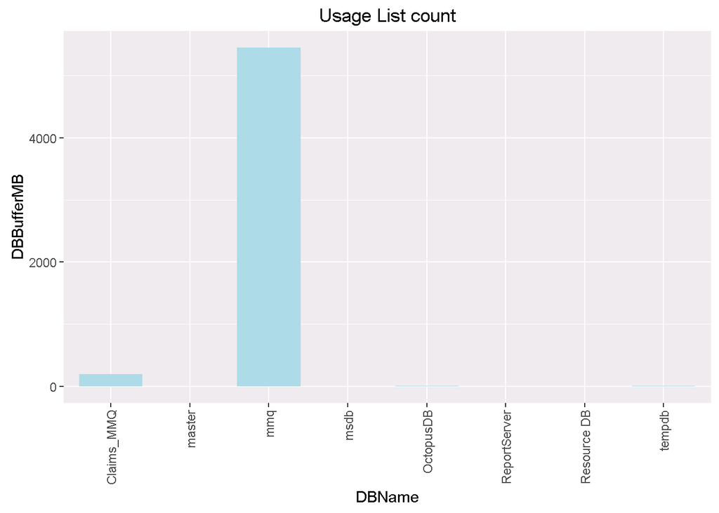

```r
# DB usage barplot
# titles
xTitle <- colnames(sqlDataFrame)[2];
yTitle <- colnames(rev(sqlDataFrame)[1]);
mainTitle <- "Usage List count";
# graph
barplot <- ggplot(sqlDataFrame, aes(x = factor(DBName), y = DBBufferMB)) +
  geom_bar(stat = "identity", width = 0.8, position = "dodge", fill = "lightblue") +
  xlab(xTitle) + ylab(yTitle) + ggtitle(mainTitle) +
  theme(axis.text.x=element_text(angle=90,hjust=1,vjust=0.5));
barplot;
```

## Screening Model

```r
###
for (dbInstance in dbList) {
  write(dbInstance, stdout());
  # select DB
  sqlInstance <- paste0(c("USE ", dbInstance, ";"), sep = "", collapse = "");
  # write(sqlInstance, stdout());
  sqlQuery(simmqODBC, sqlInstance);
}
```

```
## Claims_MMQ
## mmq
```

### Object Analysis

```
## Claims_MMQ
## SELECT     CASE TYPE         WHEN 'U'             THEN 'User Defined Tables'         WHEN 'S'             THEN 'System Tables'         WHEN 'IT'             THEN 'Internal Tables'         WHEN 'P'             THEN 'Stored Procedures'         WHEN 'PC'             THEN 'CLR Stored Procedures'     …
## 8
```

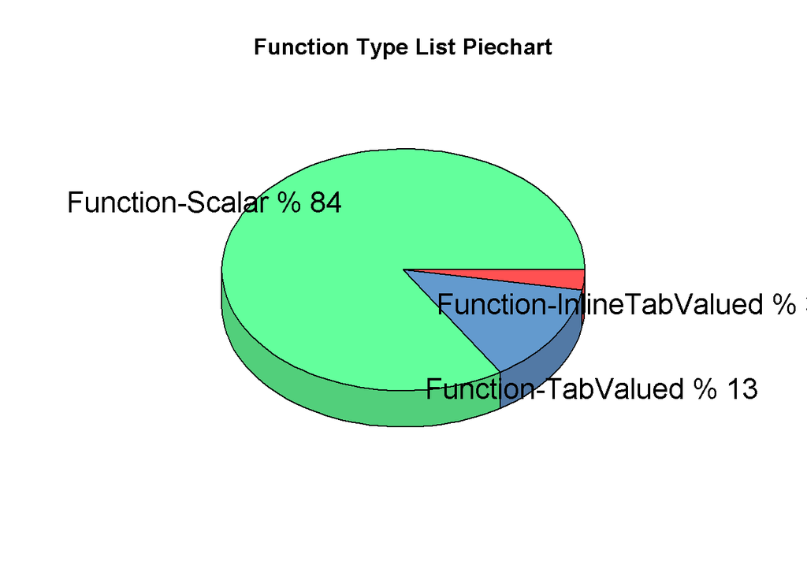

```
## mmq
## SELECT     CASE TYPE         WHEN 'U'             THEN 'User Defined Tables'         WHEN 'S'             THEN 'System Tables'         WHEN 'IT'             THEN 'Internal Tables'         WHEN 'P'             THEN 'Stored Procedures'         WHEN 'PC'             THEN 'CLR Stored Procedures'     …
## 8
```

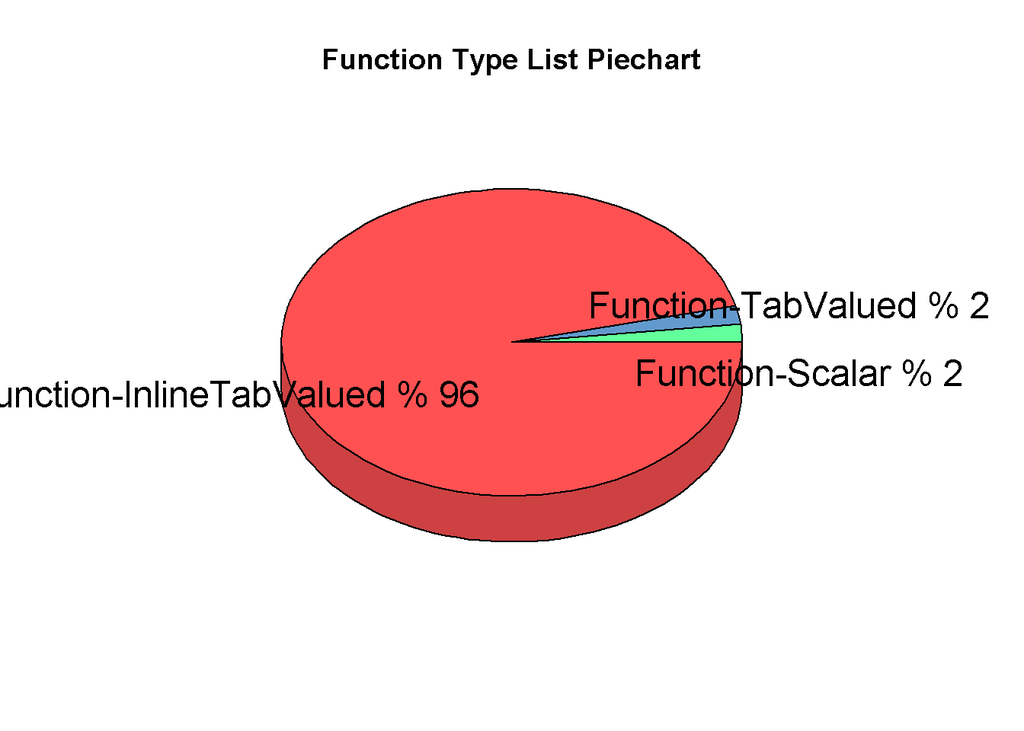

```r
###
for (dbInstance in dbList) {
  write(dbInstance, stdout());
  # select DB
  sqlInstance <- paste0(c("USE ", dbInstance, ";"), sep = "", collapse = "");
  # write(sqlInstance, stdout());
  sqlQuery(simmqODBC, sqlInstance);
  ## DB Object
  # DB object list
  sqlFile <- "SQL/DB-Object_list.sql";
  objectListDataFrame <- SqlResultToDataFrame(simmqODBC, GetSqlFromFile(sqlFile));
  head(objectListDataFrame);
  # DB object list sum fonctions
  objectSumDataFrame <- SummarizeDBFunctionDataFrame(objectListDataFrame, "Function");
  head(objectSumDataFrame);
  # titles
  xTitle <- colnames(objectSumDataFrame)[1];
  yTitle <- colnames(objectSumDataFrame)[-1];
  mainTitle <- "ObjectList count";
  # graph
  barplot <- ggplot(objectSumDataFrame, aes(x = factor(ObjectName), y = ObjectCount)) +
    geom_bar(stat = "identity", width = 0.8, position = "dodge", fill = "lightblue") +
    xlab(xTitle) + ylab(yTitle) + ggtitle(mainTitle);
  barplot;
  # DB object list all fonctions
  objectAllDataFrame <- SummarizeAllDBFunctionDataFrame(objectListDataFrame, "Function");
  head(objectAllDataFrame);
  # titles
  xTitle <- colnames(objectAllDataFrame)[1];
  yTitle <- colnames(objectAllDataFrame)[-1];
  mainTitle <- "Function Types Barplot";
  # graph
  aBarplot <- ggplot(objectAllDataFrame,
                     aes(x = "", y = FunctionCount, fill = FunctionTypes)) +
    labs(fill = xTitle) + geom_bar(width = 1, stat = "identity") +
    xlab(xTitle) + ylab(yTitle) + ggtitle(mainTitle);
  aBarplot;
  PercentList <- round(objectAllDataFrame$FunctionCount / sum(objectAllDataFrame$FunctionCount) * 100);
  ColorList <- c("#66FF99", "#6699CC", "#FF5050");
  # titles
  xTitle <- colnames(objectAllDataFrame)[1];
  yTitle <- colnames(objectAllDataFrame)[-1];
  mainTitle <- "Function Type List Piechart";
  # graph
  pie3D(objectAllDataFrame$FunctionCount,
        labels = paste(objectAllDataFrame$FunctionTypes, paste("%", PercentList)),
        main = mainTitle,
        theta = pi / 3,
        col = ColorList);
}
```

### Procedure Analysis

```r
###
for (dbInstance in dbList) {
  write(dbInstance, stdout());
  # select DB
  sqlInstance <- paste0(c("USE ", dbInstance, ";"), sep = "", collapse = "");
  # write(sqlInstance, stdout());
  sqlQuery(simmqODBC, sqlInstance);
  ## DB StoredProc
  # DB StoreProc count
  sqlFile <- "SQL/DB-Procedure_count.sql";
  countStoreProc <- SqlCountResultToInteger(simmqODBC, GetSqlFromFile(sqlFile));
  # DB StoreProc list
  sqlFile <- "SQL/DB-Procedure_list.sql";
  sqlDataFrame <- SqlResultToDataFrame(simmqODBC, GetSqlFromFile(sqlFile));
  head(sqlDataFrame);
  # DB StoreProc param list
  sqlFile <- "SQL/DB-Procedure_listParams.sql";
  storedProcParamDataFrame <- SqlResultToDataFrame(simmqODBC, GetSqlFromFile(sqlFile));
  head(storedProcParamDataFrame);
  storedProcParamDataFrameSlim <- DataFrameFromColumns(storedProcParamDataFrame,
                                                        "ProcedureName",
                                                        "ProcedureType",
                                                        "ProcedureDesc");
  head(storedProcParamDataFrameSlim);
  # DB StoreProc repeat count
  storedProcParamDataFrameFat <- aggregate(list(NbParameters = rep(1, nrow(storedProcParamDataFrameSlim))),
                                            storedProcParamDataFrameSlim,
                                            length);
  head(storedProcParamDataFrameFat);
  write(summary(rev(storedProcParamDataFrameFat)[1]), stdout());
  # DB StoreProc with params
  countStoreProcWith <- nrow(storedProcParamDataFrameFat);
  # DB StoreProc without params
  countStoreProcWithout <- countStoreProc - countStoreProcWith;
  # DB StoreProc data frame params
  storeProcParamsDF <- DataFrameWithoutWithTotal(countStoreProcWithout,
                                                 countStoreProcWith,
                                                 countStoreProc,
                                                 "StoreProc");
  # DB StoreProc param list export
  head(storeProcParamsDF);
  # DB StoreProc barplot
    OutputType <- "StoredProc";
    # rm totals/ last column & save colnames
    storeProcParamsDF <- rev(storeProcParamsDF)[-1];
    myColNames <- colnames(storeProcParamsDF);
    # rm colname and transpose and rm new colname
    colnames(storeProcParamsDF) <- NULL;
    storeProcParamsDF <- t(storeProcParamsDF);
    colnames(storeProcParamsDF) <- NULL;
    # add columns and replace colname
    storeProcParamsDF <- cbind(myColNames, storeProcParamsDF);
    colnames(storeProcParamsDF) <- NULL;
    colnames(storeProcParamsDF) <- c(paste0(OutputType, "Types"), paste0(OutputType, "Count"));
    # cast to data frame
    storeProcParamsDF <- as.data.frame(storeProcParamsDF);
    # check colname
    write(colnames(storeProcParamsDF), stdout());
    # titles
    xTitle <- colnames(storeProcParamsDF)[1];
    yTitle <- colnames(storeProcParamsDF)[-1];
    mainTitle <- paste0(OutputType, " Type List Barplot");
    # graph
    aBarplot <- ggplot(storeProcParamsDF,
                aes(x = "", y = StoredProcCount, fill = StoredProcTypes)) +
                labs(fill = xTitle) + geom_bar(width = 1, stat = "identity") +
                xlab(xTitle) + ylab(yTitle) + ggtitle(mainTitle);
    aBarplot;
  # DB StoreProc boxplot
    # titles
    xTitle <- "Procedure type";
    yTitle <- "Number of parameters";
    mainTitle <- "Boxplot for parameter distribution";
    # graph
    aBoxplot <- ggplot(storedProcParamDataFrameFat, aes(x = ProcedureType, y = NbParameters)) +
        geom_boxplot(aes(fill = ProcedureType)) + geom_jitter() +
        # + geom_point(aes(colour = factor(type_desc)), size=4)
        scale_y_continuous(breaks = seq(0, 12, 1.0)) + labs(title = mainTitle, x = xTitle, y = yTitle);
    aBoxplot;
  # DB StoreProc density plot
    # titles
    xTitle <- "Number of parameters";
    mainTitle <- "Densityplot for parameter distribution";
    # graph
    aDensityplot <- ggplot(storedProcParamDataFrameFat, aes(NbParameters, fill = ProcedureType)) +
                    geom_density(alpha = 0.6) + labs(title = mainTitle, x = xTitle);
    aDensityplot;
}
```

```
## Claims_MMQ
## SELECT  COUNT(*) FROM    information_schema.routines WHERE   routine_type = 'PROCEDURE' ;
## 810
## SELECT         name                              AS ProcedureName         , object_id                       AS ProcedureID         , type                            AS ProcedureType         , type_desc                       AS ProcedureDesc         , create_date                     AS ProcedureCr…
## 810
## SELECT          SYSO.[name]                        AS ProcedureName         ,SCHEMA_NAME(SCHEMA_ID)            AS SchemaName         , SYSO.type                        AS ProcedureType         ,SYSO.type_desc                    AS ProcedureDesc         ,SYSP.parameter_id                 AS Parame…
## 5664
## ProcedureName
## ProcedureType
## ProcedureDesc
## 1 3 4
## Min.   :  1.000
## 1st Qu.:  2.000
## Median :  3.000
## Mean   :  7.791
## 3rd Qu.:  6.500
## Max.   :145.000
## StoredProcTypes
## StoredProcCount
## mmq
## SELECT  COUNT(*) FROM    information_schema.routines WHERE   routine_type = 'PROCEDURE' ;
## 76
## SELECT         name                              AS ProcedureName         , object_id                       AS ProcedureID         , type                            AS ProcedureType         , type_desc                       AS ProcedureDesc         , create_date                     AS ProcedureCr…
## 76
## SELECT          SYSO.[name]                        AS ProcedureName         ,SCHEMA_NAME(SCHEMA_ID)            AS SchemaName         , SYSO.type                        AS ProcedureType         ,SYSO.type_desc                    AS ProcedureDesc         ,SYSP.parameter_id                 AS Parame…
## 100
## ProcedureName
## ProcedureType
## ProcedureDesc
## 1 3 4
## Min.   :1.000
## 1st Qu.:1.000
## Median :1.000
## Mean   :2.041
## 3rd Qu.:3.000
## Max.   :7.000
## StoredProcTypes
## StoredProcCount
```

### DB Analysis

```r
###
for (dbInstance in dbList) {
  write(dbInstance, stdout());
  # select DB
  sqlInstance <- paste0(c("USE ", dbInstance, ";"), sep = "", collapse = "");
  # write(sqlInstance, stdout());
  sqlQuery(simmqODBC, sqlInstance);
  ## DB Table Count
  # DB Table Count DROP
  sqlQuery(simmqODBC, "IF OBJECT_ID(N'#counts', N'U') IS NOT NULL DROP TABLE #counts;")
  # DB TABLE Count CREATE
  sqlQuery(simmqODBC, "CREATE TABLE #counts (TableName VARCHAR(255), TableRows INT);");
  # DB Table Count EXEC
  sqlQuery(simmqODBC, "EXEC sp_MSForEachTable @command1='INSERT #counts (TableName, TableRows) SELECT ''?'', COUNT(*) FROM ?';");
  # DB Table Count CSV
  sqlFile <- "SQL/DB-RowCount_list.sql";
  tableRowCountDataFrame <- SqlResultToDataFrame(simmqODBC, GetSqlFromFile(sqlFile));
  head(tableRowCountDataFrame);
  # DB Table Count repeats
  tableRowCountDataFrame <- aggregate(list(RowRepeats = rep(1, nrow(tableRowCountDataFrame[-1]))),
                                   tableRowCountDataFrame[-1],
                                   length);
  head(tableRowCountDataFrame);
  # DB Table Count half > mean repeats
  aMean <- mean(tableRowCountDataFrame$RowRepeats);
  tableRowCountDataFrame <- subset(tableRowCountDataFrame, RowRepeats > aMean);
  head(tableRowCountDataFrame);
    # titles
    xTitle <- colnames(tableRowCountDataFrame)[1];
    yTitle <- colnames(rev(tableRowCountDataFrame)[1]);
    mainTitle <- "Row List count";
    # graph
    barplot <- ggplot(tableRowCountDataFrame, aes(x = factor(TableRows), y = RowRepeats)) +
                ##barplot <- ggplot(tableRowCountDataFrame, aes(x = factor(TableRows), y = sqrt(RowRepeats))) +
                geom_bar(stat = "identity", width = 0.8, position = "dodge", fill = "lightblue") +
                ##scale_y_sqrt(paste0("Square root of ", yTitle)) +
                xlab(xTitle) + ylab(yTitle) + ggtitle(mainTitle) +
                theme(axis.text.x=element_text(angle=90,hjust=1,vjust=0.5));
    barplot;
  # DB Table Count DROP
  sqlQuery(simmqODBC, "DROP TABLE #counts;");
}
```

```
## Claims_MMQ
## SELECT  TableName         , TableRows FROM    #counts ORDER BY         TableRows DESC ;
## 348
## mmq
## SELECT  TableName         , TableRows FROM    #counts ORDER BY         TableRows DESC ;
## 605
```

### Table Analysis

```r
###
for (dbInstance in dbList) {
  write(dbInstance, stdout());
  # select DB
  sqlInstance <- paste0(c("USE ", dbInstance, ";"), sep = "", collapse = "");
  # write(sqlInstance, stdout());
  sqlQuery(simmqODBC, sqlInstance);
  ## DB Table Analysis
  # DB Table Analysis count
  sqlFile <- "SQL/DB-Table_count.sql";
  countTable <- SqlCountResultToInteger(simmqODBC, GetSqlFromFile(sqlFile));
  head(sqlDataFrame);
  # DB Table Analysis list
  sqlFile <- "SQL/DB-Table_list.sql";
  sqlDataFrame <- SqlResultToDataFrame(simmqODBC, GetSqlFromFile(sqlFile));
  head(sqlDataFrame);
  # DB Table Analysis Independent
  sqlFile <- "SQL/DB-TableIndependent_list.sql";
  sqlDataFrame <- SqlResultToDataFrame(simmqODBC, GetSqlFromFile(sqlFile));
  head(sqlDataFrame);
  # DB Table Analysis Trunk
  sqlFile <- "SQL/DB-TableTrunk_list.sql";
  sqlDataFrame <- SqlResultToDataFrame(simmqODBC, GetSqlFromFile(sqlFile));
  head(sqlDataFrame);
  # DB Table Analysis Branch
  sqlFile <- "SQL/DB-TableBranch_list.sql";
  sqlDataFrame <- SqlResultToDataFrame(simmqODBC, GetSqlFromFile(sqlFile));
  head(sqlDataFrame);
  # DB Table Analysis Leaf
  sqlFile <- "SQL/DB-TableLeaf_list.sql";
  sqlDataFrame <- SqlResultToDataFrame(simmqODBC, GetSqlFromFile(sqlFile));
  head(sqlDataFrame);
  # DB Table Analysis Parent
  sqlFile <- "SQL/DB-TableParent_list.sql";
  sqlDataFrame <- SqlResultToDataFrame(simmqODBC, GetSqlFromFile(sqlFile));
  head(sqlDataFrame);
  # DB Table Analysis Child
  sqlFile <- "SQL/DB-TableChild_list.sql";
  sqlDataFrame <- SqlResultToDataFrame(simmqODBC, GetSqlFromFile(sqlFile));
  head(sqlDataFrame);
  # DB Table Analysis SelfRef
  sqlFile <- "SQL/DB-TableSelfRef_list.sql";
  sqlDataFrame <- SqlResultToDataFrame(simmqODBC, GetSqlFromFile(sqlFile));
  head(sqlDataFrame);
  # DB Table Analysis keys list
  sqlFile <- "SQL/DB-Table_listKeys.sql";
  sqlDataFrame <- SqlResultToDataFrame(simmqODBC, GetSqlFromFile(sqlFile));
  head(sqlDataFrame);
}
```

```
## Claims_MMQ
## SELECT  COUNT(*) FROM    sys.tables ;
## 349
## SELECT          [name]                    AS TableName         ,object_id                AS TableID         ,[type]                    AS TableType         ,type_desc                AS TableDesc         ,create_date            AS TableCreated         ,modify_date            AS TableModified      …
## 349
## SELECT         Name                    AS TableWoParentWoDependents         , object_id             AS TableID         , [type]                AS TableType         , type_desc             AS TableDesc         , create_date           AS TableCreated         , modify_date           AS TableModified…
## 186
## SELECT  DISTINCT         OBJECT_NAME(referenced_object_id)   AS TableTrunkName FROM    sys.foreign_key_columns WHERE   referenced_object_id         NOT IN         (             SELECT  parent_object_id             FROM    sys.foreign_key_columns         ) ORDER BY         TableTrunkName ;
## 45
## SELECT  DISTINCT         OBJECT_NAME(referenced_object_id)       AS TableBranchName FROM    sys.foreign_key_columns WHERE   referenced_object_id         IN         (             SELECT  parent_object_id             FROM    sys.foreign_key_columns         )         AND         parent_object_id    …
## 31
## SELECT  DISTINCT         OBJECT_NAME(parent_object_id)       AS TableLeafName FROM    sys.foreign_key_columns WHERE   parent_object_id         NOT IN         (             SELECT  referenced_object_id             FROM    sys.foreign_key_columns         ) ORDER BY         TableLeafName ;
## 83
## SELECT  DISTINCT         OBJECT_NAME(referenced_object_id)       AS TableParent         , OBJECT_NAME(parent_object_id)         AS TableChild         , OBJECT_NAME(constraint_object_id)     AS FKName FROM    sys.foreign_key_columns ORDER BY         TableParent, TableChild ;
## 217
## SELECT  DISTINCT         OBJECT_NAME(referenced_object_id)   AS TableChild FROM    sys.foreign_key_columns WHERE   referenced_object_id         IN         (             SELECT  parent_object_id             FROM    sys.foreign_key_columns         ) ORDER BY         TableChild ;
## 35
## SELECT  DISTINCT         OBJECT_NAME(referenced_object_id)                       AS ParentTableName         , COL_NAME(referenced_object_id, referenced_column_id)  AS ParentColumnName         , OBJECT_NAME(parent_object_id)                         AS ChildTableName         , COL_NAME(parent_objec…
## 1
## SELECT  PKeyTab.TableName,         PKeyTab.PKName,         FKeyTab.FKName,         PKeyTab.ColumnName FROM    (          SELECT TableName,                 PKName,                 ColumnName          FROM   (                 SELECT                 OBJECT_NAME(parent_object_id)   AS PKTableName,   …
## 403
## mmq
## SELECT  COUNT(*) FROM    sys.tables ;
## 605
## SELECT          [name]                    AS TableName         ,object_id                AS TableID         ,[type]                    AS TableType         ,type_desc                AS TableDesc         ,create_date            AS TableCreated         ,modify_date            AS TableModified      …
## 605
## SELECT         Name                    AS TableWoParentWoDependents         , object_id             AS TableID         , [type]                AS TableType         , type_desc             AS TableDesc         , create_date           AS TableCreated         , modify_date           AS TableModified…
## 196
## SELECT  DISTINCT         OBJECT_NAME(referenced_object_id)   AS TableTrunkName FROM    sys.foreign_key_columns WHERE   referenced_object_id         NOT IN         (             SELECT  parent_object_id             FROM    sys.foreign_key_columns         ) ORDER BY         TableTrunkName ;
## 65
## SELECT  DISTINCT         OBJECT_NAME(referenced_object_id)       AS TableBranchName FROM    sys.foreign_key_columns WHERE   referenced_object_id         IN         (             SELECT  parent_object_id             FROM    sys.foreign_key_columns         )         AND         parent_object_id    …
## 97
## SELECT  DISTINCT         OBJECT_NAME(parent_object_id)       AS TableLeafName FROM    sys.foreign_key_columns WHERE   parent_object_id         NOT IN         (             SELECT  referenced_object_id             FROM    sys.foreign_key_columns         ) ORDER BY         TableLeafName ;
## 232
## SELECT  DISTINCT         OBJECT_NAME(referenced_object_id)       AS TableParent         , OBJECT_NAME(parent_object_id)         AS TableChild         , OBJECT_NAME(constraint_object_id)     AS FKName FROM    sys.foreign_key_columns ORDER BY         TableParent, TableChild ;
## 686
## SELECT  DISTINCT         OBJECT_NAME(referenced_object_id)   AS TableChild FROM    sys.foreign_key_columns WHERE   referenced_object_id         IN         (             SELECT  parent_object_id             FROM    sys.foreign_key_columns         ) ORDER BY         TableChild ;
## 111
## SELECT  DISTINCT         OBJECT_NAME(referenced_object_id)                       AS ParentTableName         , COL_NAME(referenced_object_id, referenced_column_id)  AS ParentColumnName         , OBJECT_NAME(parent_object_id)                         AS ChildTableName         , COL_NAME(parent_objec…
## 20
## SELECT  PKeyTab.TableName,         PKeyTab.PKName,         FKeyTab.FKName,         PKeyTab.ColumnName FROM    (          SELECT TableName,                 PKName,                 ColumnName          FROM   (                 SELECT                 OBJECT_NAME(parent_object_id)   AS PKTableName,   …
## 1263
```

#### Table Independent List

Verify if empty or not used.

#### Table Trunk List

Verify if empty or not used. Verify if FK point to indexed columns. Verify if PK is indexed.

#### Table Branch List

Verify if empty or not used. Verify if FK point to indexed columns.

#### Table Leaf List

Verify if empty or not used. Verify if FK point to indexed columns. Verify if PK is indexed.

#### Table Parent List

Verify if empty or not used. Verify if PK is indexed.

#### Table Child List

Verify if empty or not used. Verify if FK point to indexed columns.

#### Table SelfRef List

Verify if empty or not used. Verify if FK point to indexed columns. Verify if PK is indexed.

#### Table Key List

Verify if FK point to indexed columns. Verify if PK is indexed.

### View Analysis

Check if they are indexable or indexed, index them if needed to increase performance.

```r
###
for (dbInstance in dbList) {
  write(dbInstance, stdout());
  # select DB
  sqlInstance <- paste0(c("USE ", dbInstance, ";"), sep = "", collapse = "");
  # write(sqlInstance, stdout());
  sqlQuery(simmqODBC, sqlInstance);
  ## View Analysis
  # View Analysis count
  sqlFile <- "SQL/DB-View_count.sql";
  countView <- SqlCountResultToInteger(simmqODBC, GetSqlFromFile(sqlFile));
  # View Analysis list
  sqlFile <- "SQL/DB-View_list.sql";
  sqlDataFrame <- SqlResultToDataFrame(simmqODBC, GetSqlFromFile(sqlFile));
  head(sqlDataFrame);
}
```

```
## Claims_MMQ
## SELECT  COUNT(*) FROM    sys.views ;
## 580
## SELECT            name                                        AS ViewName         , OBJECT_ID                                 AS ViewID         , type                                      AS ViewType         , type_desc                                 AS ViewDesc         , create_date            …
## 580
## mmq
## SELECT  COUNT(*) FROM    sys.views ;
## 107
## SELECT            name                                        AS ViewName         , OBJECT_ID                                 AS ViewID         , type                                      AS ViewType         , type_desc                                 AS ViewDesc         , create_date            …
## 107
```

### Function Analysis

#### Function Type List

```r
###
for (dbInstance in dbList) {
  write(dbInstance, stdout());
  # select DB
  sqlInstance <- paste0(c("USE ", dbInstance, ";"), sep = "", collapse = "");
  # write(sqlInstance, stdout());
  sqlQuery(simmqODBC, sqlInstance);
  ## Function Analysis
  # Function Analysis count
  sqlFile <- "SQL/DB-Function_count.sql";
  countFunc <- SqlCountResultToInteger(simmqODBC, GetSqlFromFile(sqlFile));
  # Function Analysis list
  sqlFile <- "SQL/DB-Function_list.sql";
  sqlDataFrame <- SqlResultToDataFrame(simmqODBC, GetSqlFromFile(sqlFile));
  head(sqlDataFrame);
}
```

```
## Claims_MMQ
## SELECT  COUNT(*) FROM    dbo.sysobjects WHERE   [type]  IN ('FN', 'IF', 'TF') ;
## 187
## SELECT    FUNCMO.FunctionName         , FUNCSO.ObjectID                    AS FunctionID         , FUNCMO.FunctionType         , FUNCMO.FunctionDesc         , FUNCMO.FunctionCreated         , FUNCMO.FunctionModified FROM (     SELECT  [name]                           AS FunctionName             ,…
## 187
## mmq
## SELECT  COUNT(*) FROM    dbo.sysobjects WHERE   [type]  IN ('FN', 'IF', 'TF') ;
## 52
## SELECT    FUNCMO.FunctionName         , FUNCSO.ObjectID                    AS FunctionID         , FUNCMO.FunctionType         , FUNCMO.FunctionDesc         , FUNCMO.FunctionCreated         , FUNCMO.FunctionModified FROM (     SELECT  [name]                           AS FunctionName             ,…
## 52
```

#### Function Parameter List

```r
###
for (dbInstance in dbList) {
  write(dbInstance, stdout());
  # select DB
  sqlInstance <- paste0(c("USE ", dbInstance, ";"), sep = "", collapse = "");
  # write(sqlInstance, stdout());
  sqlQuery(simmqODBC, sqlInstance);
  # Function Analysis param list
  sqlFile <- "SQL/DB-Function_listParams.sql";
  functionParamsDataFrame <- SqlResultToDataFrame(simmqODBC, GetSqlFromFile(sqlFile));
  head(functionParamsDataFrame);
  fnParamsDataFrameSlim <- DataFrameFromColumns(functionParamsDataFrame,
                                                "FunctionName",
                                                "FunctionType",
                                                "FunctionDesc");
  head(fnParamsDataFrameSlim);
  # Function Analysis repeat count
  fnParamsDataFrameFat <- aggregate(list(NbParameters = rep(1, nrow(fnParamsDataFrameSlim))),
                                    fnParamsDataFrameSlim,
                                    length);
  write(summary(rev(fnParamsDataFrameFat)[1]), stdout());
  # Function Analysis without params
  countFuncWith <- nrow(fnParamsDataFrameFat);
  # Function Analysis without params
  countFuncWithout <- countFunc - countFuncWith;
  # Function Analysis data frame params
  fnParamsDF <- DataFrameWithoutWithTotal(countFuncWithout,
                                          countFuncWith,
                                          countFunc,
                                          "Fn");
  # Function Analysis param list export
  head(fnParamsDF);
  # Function Analysis barplot
    OutputType <- "Fn";
    # rm totals/ last column & save colnames
    fnParamsDF <- rev(fnParamsDF)[-1];
    myColNames <- colnames(fnParamsDF);
    # rm colname and transpose and rm new colname
    colnames(fnParamsDF) <- NULL;
    fnParamsDF <- t(fnParamsDF);
    colnames(fnParamsDF) <- NULL;
    # add columns and replace colname
    fnParamsDF <- cbind(myColNames, fnParamsDF);
    colnames(fnParamsDF) <- NULL;
    colnames(fnParamsDF) <- c(paste0(OutputType, "Types"), paste0(OutputType, "Count"));
    # cast to data frame
    fnParamsDF <- as.data.frame(fnParamsDF);
    # check colname
    write(colnames(fnParamsDF), stdout());
    # titles
    xTitle <- colnames(fnParamsDF)[1];
    yTitle <- colnames(fnParamsDF)[-1];
    mainTitle <- paste0(OutputType, " Type List Barplot");
    # graph
    aBarplot <- ggplot(fnParamsDF, aes(x = "", y = FnCount, fill = FnTypes)) +
                labs(fill = xTitle) + geom_bar(width = 1, stat = "identity") +
                xlab(xTitle) + ylab(yTitle) + ggtitle(mainTitle);
    aBarplot;
  # Function Analysis boxplot
    xTitle <- "Function type";
    yTitle <- "Number of parameters";
    mainTitle <- "Boxplot for parameter distribution";
    # graph
    aBoxplot <- ggplot(fnParamsDataFrameFat, aes(x = FunctionType, y = NbParameters)) +
                geom_boxplot(aes(fill = FunctionType)) + geom_jitter() +
    # + geom_point(aes(colour = factor(type_desc)), size=4)
                scale_y_continuous(breaks = seq(0, 12, 1.0)) + labs(title = mainTitle, x = xTitle, y = yTitle);
    aBoxplot;
  # Function Analysis density plot
    # titles
    xTitle <- "Number of parameters";
    mainTitle <- "Densityplot for parameter distribution";
    # graph
    aDensityplot <- ggplot(fnParamsDataFrameFat, aes(NbParameters, fill = FunctionType)) +
                    geom_density(alpha = 0.6) + labs(title = mainTitle, x = xTitle);
    aDensityplot;
}
```

```
## Claims_MMQ
## SELECT            SYSO.[name]                     AS FunctionName         ,SCHEMA_NAME(SCHEMA_ID)         AS SchemaName         ,SYSO.type                      AS FunctionType         ,SYSO.type_desc                 AS FunctionDesc         ,SYSP.parameter_id              AS ParameterID         ,S…
## 448
## FunctionName
## FunctionType
## FunctionDesc
## 1 3 4
## Min.   : 1.000
## 1st Qu.: 2.000
## Median : 2.000
## Mean   : 2.545
## 3rd Qu.: 3.000
## Max.   :12.000
## FnTypes
## FnCount
## mmq
## SELECT            SYSO.[name]                     AS FunctionName         ,SCHEMA_NAME(SCHEMA_ID)         AS SchemaName         ,SYSO.type                      AS FunctionType         ,SYSO.type_desc                 AS FunctionDesc         ,SYSP.parameter_id              AS ParameterID         ,S…
## 91
## FunctionName
## FunctionType
## FunctionDesc
## 1 3 4
## Min.   :1.00
## 1st Qu.:1.00
## Median :2.00
## Mean   :1.75
## 3rd Qu.:2.00
## Max.   :4.00
## FnTypes
## FnCount
```

Check why certain procedures have so many parameters.

### Principal Key Analysis

Check if all are used nor indexed.

```r
###
for (dbInstance in dbList) {
  write(dbInstance, stdout());
  # select DB
  sqlInstance <- paste0(c("USE ", dbInstance, ";"), sep = "", collapse = "");
  # write(sqlInstance, stdout());
  sqlQuery(simmqODBC, sqlInstance);
  ## PKey Analysis
  # PKey Analysis count
  sqlFile <- "SQL/DB-PKeys_count.sql";
  countPKeys <- SqlCountResultToInteger(simmqODBC, GetSqlFromFile(sqlFile));
  # PKey Analysis list
  sqlFile <- "SQL/DB-PKeys_list.sql";
  sqlDataFrame <- SqlResultToDataFrame(simmqODBC, GetSqlFromFile(sqlFile));
  head(sqlDataFrame);
}
```

```
## Claims_MMQ
## SELECT  COUNT(*) FROM (  SELECT  OBJECT_NAME(parent_object_id)   AS PKTableName,     OBJECT_NAME(OBJECT_ID)          AS PKName   FROM    sys.objects     WHERE   type_desc IN ('PRIMARY_KEY_CONSTRAINT') )                                   AS PKTab LEFT OUTER JOIN (  SELECT          Table_Name      …
## 283
## SELECT       PKTab.TableName         , ColumnName        , PrincipalKey      , PrincipalKeyID        , PKCreated         , PKModified        , PKOrdinal FROM (  SELECT          OBJECT_NAME(parent_object_id)       AS TableName            , OBJECT_NAME(OBJECT_ID)            AS PrincipalKey         …
## 283
## mmq
## SELECT  COUNT(*) FROM (  SELECT  OBJECT_NAME(parent_object_id)   AS PKTableName,     OBJECT_NAME(OBJECT_ID)          AS PKName   FROM    sys.objects     WHERE   type_desc IN ('PRIMARY_KEY_CONSTRAINT') )                                   AS PKTab LEFT OUTER JOIN (  SELECT          Table_Name      …
## 646
## SELECT       PKTab.TableName         , ColumnName        , PrincipalKey      , PrincipalKeyID        , PKCreated         , PKModified        , PKOrdinal FROM (  SELECT          OBJECT_NAME(parent_object_id)       AS TableName            , OBJECT_NAME(OBJECT_ID)            AS PrincipalKey         …
## 646
```

### Foreign Key Analysis

Check if all are used nor indexed nor trusted. Verify tables if ON Delete CASCADE.

```r
###
for (dbInstance in dbList) {
  write(dbInstance, stdout());
  # select DB
  sqlInstance <- paste0(c("USE ", dbInstance, ";"), sep = "", collapse = "");
  # write(sqlInstance, stdout());
  sqlQuery(simmqODBC, sqlInstance);
  ## FKey Analysis
  # FKey Analysis count
  sqlFile <- "SQL/DB-FKeys_count.sql";
  countFKeys <- SqlCountResultToInteger(simmqODBC, GetSqlFromFile(sqlFile));
  # FKey Analysis list
  sqlFile <- "SQL/DB-FKeys_list.sql";
  sqlDataFrame <- SqlResultToDataFrame(simmqODBC, GetSqlFromFile(sqlFile));
  head(sqlDataFrame);
}
```

```
## Claims_MMQ
## SELECT  COUNT(*) FROM    sys.foreign_key_columns     AS fk JOIN    sys.tables                  AS t ON      fk.parent_object_id = t.object_id JOIN    sys.columns                 AS c ON      fk.parent_object_id = c.object_id         AND         fk.parent_column_id = c.column_id ;
## 220
## SELECT          OBJECT_NAME(SYSFK.parent_object_id)                          AS TableName         , COL_NAME(FC.parent_object_id, FC.parent_column_id)         AS ColumnName         , SYSFK.name                                                 AS ForeignKey         , SYSFK.object_id                …
## 220
## mmq
## SELECT  COUNT(*) FROM    sys.foreign_key_columns     AS fk JOIN    sys.tables                  AS t ON      fk.parent_object_id = t.object_id JOIN    sys.columns                 AS c ON      fk.parent_object_id = c.object_id         AND         fk.parent_column_id = c.column_id ;
## 741
## SELECT          OBJECT_NAME(SYSFK.parent_object_id)                          AS TableName         , COL_NAME(FC.parent_object_id, FC.parent_column_id)         AS ColumnName         , SYSFK.name                                                 AS ForeignKey         , SYSFK.object_id                …
## 741
```

### Index Analysis

#### Index List

```r
###
for (dbInstance in dbList) {
  write(dbInstance, stdout());
  # select DB
  sqlInstance <- paste0(c("USE ", dbInstance, ";"), sep = "", collapse = "");
  # write(sqlInstance, stdout());
  sqlQuery(simmqODBC, sqlInstance);
  ## Index Analysis
  # Index Analysis count
  sqlFile <- "SQL/DB-Index_count.sql";
  countIndex <- SqlCountResultToInteger(simmqODBC, GetSqlFromFile(sqlFile));
  # Index Analysis list
  sqlFile <- "SQL/DB-Index_list.sql";
  sqlDataFrame <- SqlResultToDataFrame(simmqODBC, GetSqlFromFile(sqlFile));
  head(sqlDataFrame);
  # Index Analysis type list
  sqlFile <- "SQL/DB-Index_listTypes.sql";
  sqlDataFrame <- SqlResultToDataFrame(simmqODBC, GetSqlFromFile(sqlFile));
  head(sqlDataFrame);
}
```

```
## Claims_MMQ
## SELECT   COUNT(*) FROM ( SELECT  ISNULL(name,'NA')                       AS IndexName            , object_id                             AS IndexID          , type                                  AS IndexType            , type_desc                             AS IndexDesc            , is_unique …
## 643
## SELECT         DB_NAME()                                       AS DBName         , OBJECT_NAME(parent_object_id)                 AS TableName         , parent_column_id                              AS ColumnNumber         , COL_NAME(parent_object_id, parent_column_id)  AS ColumnName         , Nam…
## 0
## SELECT                SYSO.name                                   AS TableName         , SYSO.type                                 AS TableType         , SYSO.type_desc                            AS TableDesc         , SYSP.index_id                             AS TableIndexID         , COALESCE(S…
## 679
## mmq
## SELECT   COUNT(*) FROM ( SELECT  ISNULL(name,'NA')                       AS IndexName            , object_id                             AS IndexID          , type                                  AS IndexType            , type_desc                             AS IndexDesc            , is_unique …
## 1151
## SELECT         DB_NAME()                                       AS DBName         , OBJECT_NAME(parent_object_id)                 AS TableName         , parent_column_id                              AS ColumnNumber         , COL_NAME(parent_object_id, parent_column_id)  AS ColumnName         , Nam…
## 4
## SELECT                SYSO.name                                   AS TableName         , SYSO.type                                 AS TableType         , SYSO.type_desc                            AS TableDesc         , SYSP.index_id                             AS TableIndexID         , COALESCE(S…
## 1216
```

Verify Constraint Type. Verify if can lock page.

#### Index Type List

```r
###
for (dbInstance in dbList) {
  write(dbInstance, stdout());
  # select DB
  sqlInstance <- paste0(c("USE ", dbInstance, ";"), sep = "", collapse = "");
  # write(sqlInstance, stdout());
  sqlQuery(simmqODBC, sqlInstance);
  # Index Analysis type list
  sqlFile <- "SQL/DB-Index_listTypes.sql";
  sqlDataFrame <- SqlResultToDataFrame(simmqODBC, GetSqlFromFile(sqlFile));
  head(sqlDataFrame);
}
```

```
## Claims_MMQ
## SELECT                SYSO.name                                   AS TableName         , SYSO.type                                 AS TableType         , SYSO.type_desc                            AS TableDesc         , SYSP.index_id                             AS TableIndexID         , COALESCE(S…
## 679
## mmq
## SELECT                SYSO.name                                   AS TableName         , SYSO.type                                 AS TableType         , SYSO.type_desc                            AS TableDesc         , SYSP.index_id                             AS TableIndexID         , COALESCE(S…
## 1216
```

Verify Index Type. Verify if indexed.

### Constraint Analysis

Validate if constraint is respected.

```r
###
for (dbInstance in dbList) {
  write(dbInstance, stdout());
  # select DB
  sqlInstance <- paste0(c("USE ", dbInstance, ";"), sep = "", collapse = "");
  # write(sqlInstance, stdout());
  sqlQuery(simmqODBC, sqlInstance);
  ## Constraint Analysis
  # Constraint Analysis List
  sqlFile <- "SQL/DB-Constraint_list.sql";
  sqlDataFrame <- SqlResultToDataFrame(simmqODBC, GetSqlFromFile(sqlFile));
  head(sqlDataFrame);
}
```

```
## Claims_MMQ
## SELECT         DB_NAME()                                       AS DBName         , OBJECT_NAME(parent_object_id)                 AS TableName         , parent_column_id                              AS ColumnNumber         , COL_NAME(parent_object_id, parent_column_id)  AS ColumnName         , Nam…
## 0
## mmq
## SELECT         DB_NAME()                                       AS DBName         , OBJECT_NAME(parent_object_id)                 AS TableName         , parent_column_id                              AS ColumnNumber         , COL_NAME(parent_object_id, parent_column_id)  AS ColumnName         , Nam…
## 4
```

```r
# RODBC close SimmqDB
odbcClose(simmqODBC);
```

## Screening Code Calls

The minimum DB structure to have is to find al calls to DB from code.

### VB.NET Files

```bash
find /mnt/C/Disk_X/axon/mmqclaims -name "*.vb" | cat | while read i ; do echo "$i" ; done > Claims_MMQ-VB.NET_files.txt
```

### C# Files

```bash
find /mnt/C/Disk_X/axon/mmqclaims -name "*.cs" | cat | while read i ; do echo "$i" ; done > Claims_MMQ-CSharp_files.txt
```

### Java Files

```bash
find /mnt/C/Disk_X/axon/autoquick -name "*.java" | cat | while read i ; do echo "$i" ; done > mmq-Java_files.txt
```